# R Notebook: Boosting

# Recap

$$G(x)=\textrm{sign}\left( \sum_{m=1}^M \alpha_mG_m(x) \right),$$
where $\alpha_1,\cdots,\alpha_m$ are computed by the booting algorithm, and weight the contribution of each respective $G_m(x)$.

Comparison of bagging and boosting:

Bagging: taking multiple subsets of the training data set, then building multiple independent decision tree models, and then average the models allowing to create a very performant predictive model compared to the classical CART model.

Boosting: similar to the bagging method, except that the trees are grown sequentially: each successive tree is grown using information from previously grown trees, with the aim to minimize the error of the previous models.

# Adaboosting

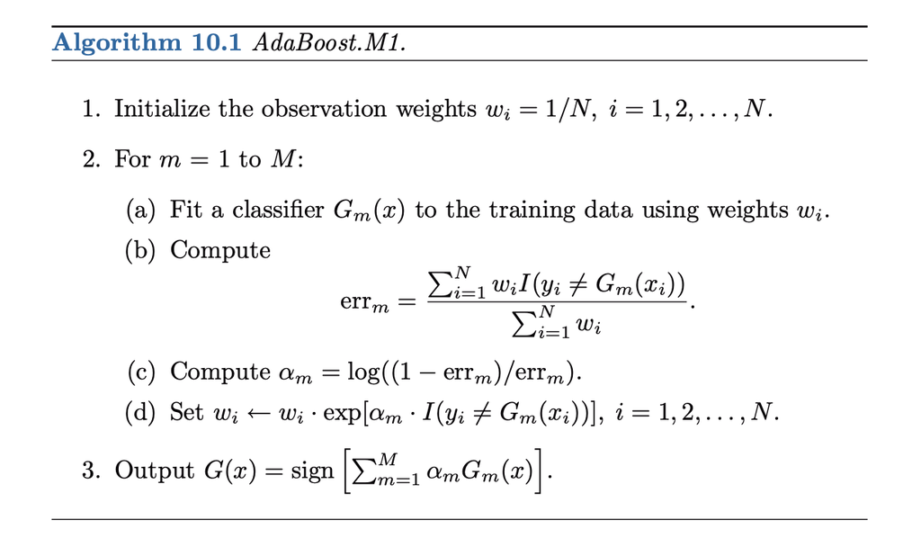

```r
# Adaboosting Algorithm
library(adabag)
library(caret)
data("iris")

# creat training and test data
set.seed(42)
index <- createDataPartition(iris$Species , p =0.7, list = FALSE)
train.iris <- iris[index,]
test.iris <- iris[-index,]

# Create the Model without Cross Validation with the help of Boosting Function
model = boosting(Species~., data = train.iris, boos = TRUE, mfinal = 50)

# Prediction of the Test Data
pred = predict(model , test.iris)
pred$confusion
```

```
##                Observed Class
## Predicted Class setosa versicolor virginica
##      setosa         15          0         0
##      versicolor      0         14         2
##      virginica       0          1        13
```

```r
# Training the Data with Boosting with Cross Validation
cvmodel = boosting.cv(Species ~., data = iris, boos = TRUE, mfinal = 10, v =5)
```

```
## i:  1 Tue Oct  5 23:24:13 2021
## i:  2 Tue Oct  5 23:24:16 2021
## i:  3 Tue Oct  5 23:24:19 2021
## i:  4 Tue Oct  5 23:24:21 2021
## i:  5 Tue Oct  5 23:24:24 2021
```

```r
cvmodel$confusion
```

```
##                Observed Class
## Predicted Class setosa versicolor virginica
##      setosa         50          0         0
##      versicolor      0         45         4
##      virginica       0          5        46
```

# Gradient Boosting Using GBM Package

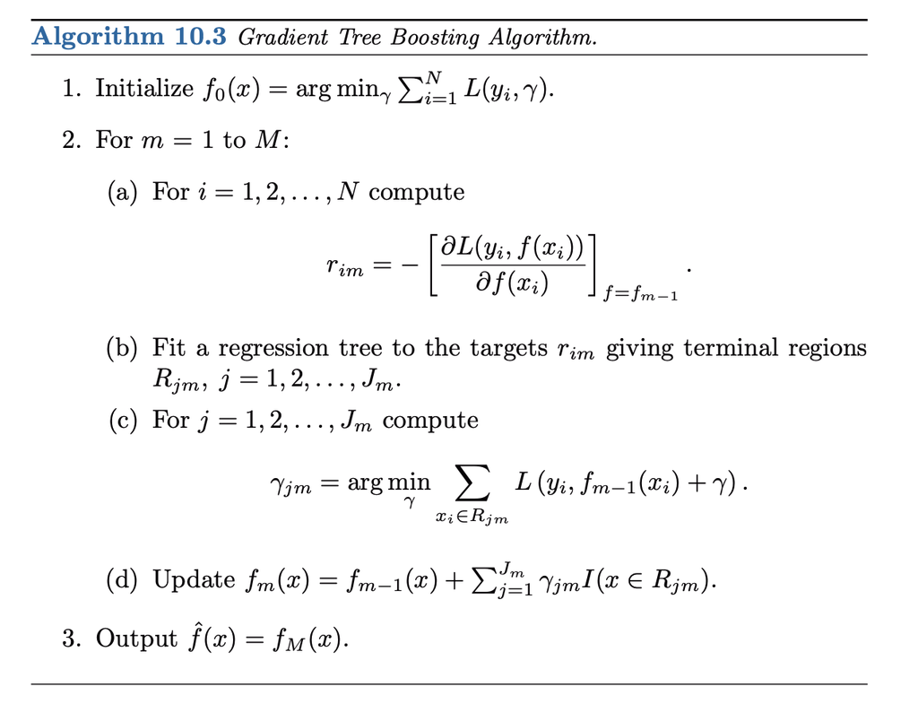

Let’s use **gbm** package in R to fit gradient boosting model.

```r
require(gbm)
require(MASS)#package with the boston housing dataset
#separating training and test data
train=sample(1:506,size=374)
```

We will use the Boston housing data to predict the median value of the houses.

```r
Boston.boost=gbm(medv ~ . ,data = Boston[train,],distribution = "gaussian",n.trees = 10000,
                  shrinkage = 0.01, interaction.depth = 4)
Boston.boost
```

```
## gbm(formula = medv ~ ., distribution = "gaussian", data = Boston[train,
##     ], n.trees = 10000, interaction.depth = 4, shrinkage = 0.01)
## A gradient boosted model with gaussian loss function.
## 10000 iterations were performed.
## There were 13 predictors of which 13 had non-zero influence.
```

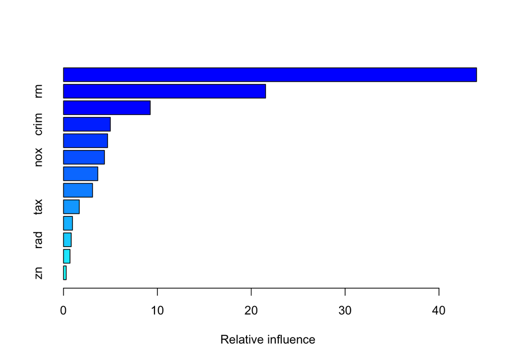

|  | var | rel.inf |
| --- | --- | --- |
| lstat | lstat | 44.0078121 |
| rm | rm | 21.5299628 |
| dis | dis | 9.2386893 |
| crim | crim | 4.9893174 |
| age | age | 4.6962608 |
| nox | nox | 4.3593864 |
| ptratio | ptratio | 3.6522566 |
| black | black | 3.0944851 |
| tax | tax | 1.6799678 |
| chas | chas | 0.9559895 |

[output cut: 3 more lines]

```r
summary(Boston.boost) #Summary gives a table of Variable Importance and a plot of Variable Importance
```

The above Boosted Model is a Gradient Boosted Model which generates 10000 trees and the shrinkage parameter $\lambda=0.01$ which is also a sort of learning rate. Next parameter is the interaction depth $d$ which is the total splits we want to do.So here each tree is a small tree with only 4 splits.

The summary of the Model gives a feature importance plot.In the above list is on the top is the most important variable and at last is the least important variable.

And the 2 most important features which explain the maximum variance in the Data set is **lstat** i.e lower status of the population (percent) and **rm** which is average number of rooms per dwelling.

## Plotting the Partial Dependence Plot

The partial Dependence Plots will tell us the relationship and dependence of the variables $X_i$ with the Response variable $Y$.

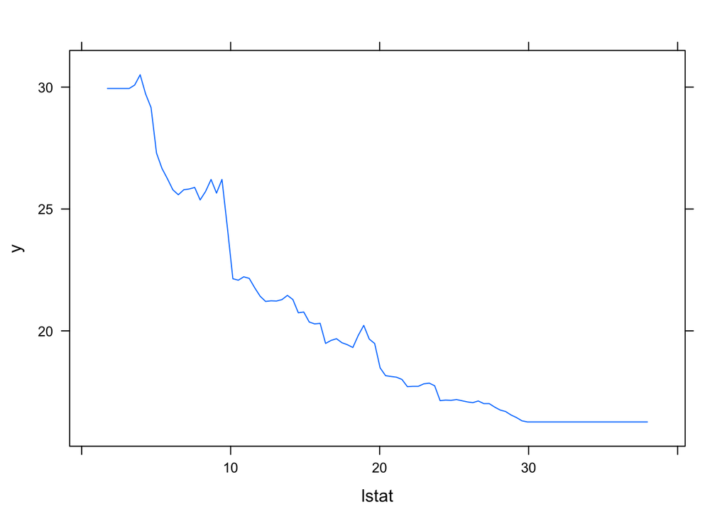

```r
#Plot of Response variable with lstat variable
plot(Boston.boost,i="lstat")
```

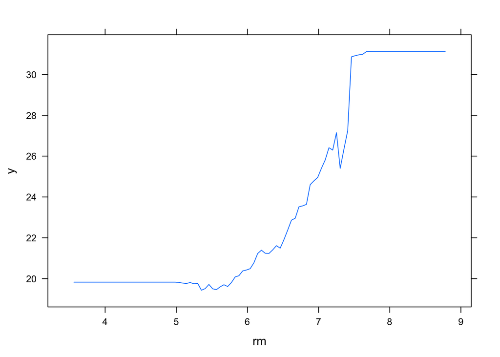

```r
#Inverse relation with lstat variable

plot(Boston.boost,i="rm")
```

```r
#as the average number of rooms increases the the price increases
```

The above plot simply shows the relation between the variables in the x-axis and the mapping function $f(x)$ on the y-axis.First plot shows that **lstat** is negatively correlated with the response mdev, whereas the second one shows that rm is somewhat directly related to **mdev**.

```r
cor(Boston$lstat,Boston$medv)#negetive correlation coeff-r
```

```
## [1] -0.7376627
```

```r
cor(Boston$rm,Boston$medv)#positive correlation coeff-r
```

```
## [1] 0.6953599
```

## Prediction on Test Set

We will compute the Test Error as a function of number of Trees.

```r
n.trees = seq(from=100 ,to=10000, by=100) #no of trees-a vector of 100 values

#Generating a Prediction matrix for each Tree
predmatrix<-predict(Boston.boost,Boston[-train,],n.trees = n.trees)
dim(predmatrix) #dimentions of the Prediction Matrix
```

```
## [1] 132 100
```

```r
#Calculating The Mean squared Test Error
test.error<-with(Boston[-train,],apply( (predmatrix-medv)^2,2,mean))
head(test.error) #contains the Mean squared test error for each of the 100 trees averaged
```

```
##      100      200      300      400      500      600
## 33.52898 18.08890 13.80592 12.24712 11.87137 11.68395
```

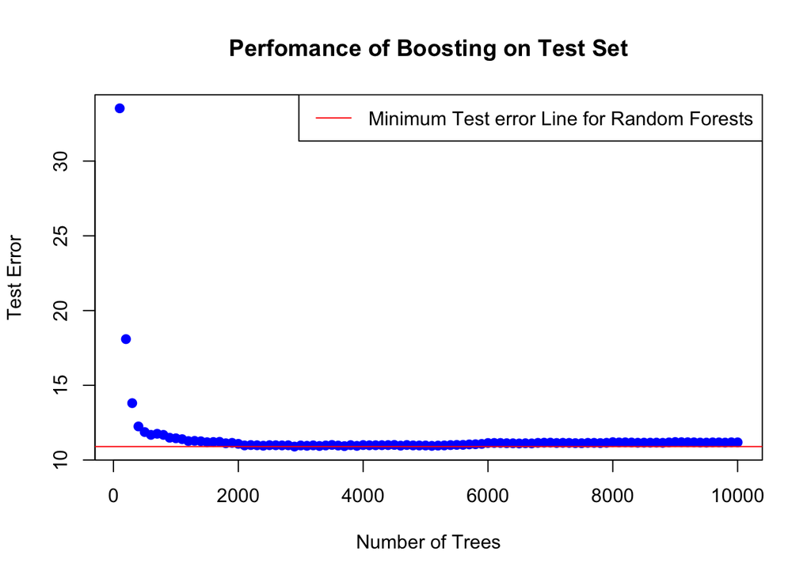

```r
#Plotting the test error vs number of trees

plot(n.trees , test.error , pch=19,col="blue",xlab="Number of Trees",ylab="Test Error", main = "Perfomance of Boosting on Test Set")

#adding the RandomForests Minimum Error line trained on same data and similar parameters
abline(h = min(test.error),col="red") #test.err is the test error of a Random forest fitted on same data
legend("topright",c("Minimum Test error Line for Random Forests"),col="red",lty=1,lwd=1)
```

## Summary

From the above plot we can notice that if boosting is done properly by selecting appropriate tuning parameters such as shrinkage parameter $\lambda$, the number of splits we want and the number of trees $n$, then it can generalize really well and convert a weak learner to strong learner. Ensembling techniques are really well and tend to outperform a single learner which is prone to either overfitting or underfitting or generate thousands or hundreds of them,then combine them to produce a better and stronger model.

# Stochastic Gradient Boosting Using XGBOOST Package

Stochastic gradient boosting involves resampling of observations and columns in each round

```r
library(tidyverse)  ## for easy data manipulation and visualization
library(caret)      ## for easy machine learning workflow
library(xgboost)    ## for computing boosting algorithm
```

Data set: **PimaIndiansDiabetes2** [in **mlbench** package], for predicting the probability of being diabetes positive based on multiple clinical variables.

Randomly split the data into training set (80% for building a predictive model) and test set (20% for evaluating the model). Make sure to set seed for reproducibility.

```r
# Load the data and remove NAs
data("PimaIndiansDiabetes2", package = "mlbench")
PimaIndiansDiabetes2 <- na.omit(PimaIndiansDiabetes2)
# Inspect the data
sample_n(PimaIndiansDiabetes2, 3)
```

|  | pregnant | glucose | pressure | triceps | insulin | mass | pedigree | age | diabetes |
| --- | --- | --- | --- | --- | --- | --- | --- | --- | --- |
| 449 | 0 | 104 | 64 | 37 | 64 | 33.6 | 0.510 | 22 | pos |
| 120 | 4 | 99 | 76 | 15 | 51 | 23.2 | 0.223 | 21 | neg |
| 422 | 2 | 94 | 68 | 18 | 76 | 26.0 | 0.561 | 21 | neg |

```r
# Split the data into training and test set
set.seed(123)
training.samples <- PimaIndiansDiabetes2$diabetes %>%
  createDataPartition(p = 0.8, list = FALSE)
train.data  <- PimaIndiansDiabetes2[training.samples, ]
test.data <- PimaIndiansDiabetes2[-training.samples, ]
```

We’ll use the **caret** workflow, which invokes the **xgboost** package, to automatically adjust the model parameter values, and fit the final best boosted tree that explains the best our data. We’ll use the following arguments in the function train(): trControl, to set up 10-fold cross validation

```r
# Fit the model on the training set
set.seed(123)
model <- train(
  diabetes ~., data = train.data, method = "xgbTree",
  trControl = trainControl("cv", number = 10)
  )
# Best tuning parameter
model$bestTune
```

|  | nrounds | max_depth | eta | gamma | colsample_bytree | min_child_weight | subsample |
| --- | --- | --- | --- | --- | --- | --- | --- |
| 58 | 50 | 1 | 0.4 | 0 | 0.6 | 1 | 0.75 |

```r
# Make predictions on the test data
predicted.classes <- model %>% predict(test.data)
head(predicted.classes)
```

```
## [1] neg neg pos pos neg neg
## Levels: neg pos
```

```r
# Compute model prediction accuracy rate
mean(predicted.classes == test.data$diabetes)
```

```
## [1] 0.7948718
```

The function **varImp()** [in caret] displays the importance of variables in percentage:

```r
varImp(model)
```

```
## xgbTree variable importance
##
##          Overall
## glucose   100.00
## insulin    66.71
## age        51.86
## mass       43.25
## pedigree   11.31
## triceps    10.70
## pregnant   10.31
## pressure    0.00
```